# 交易类因子

量化投资部

## 0、加载数据

```r
#  -------single factor test step by step  -----
fls <- buildFactorLists(
  buildFactorList(factorFun = "gf.volatility",
                  factorDir = -1,
                  factorPar=list(),
                  factorName = "VOL_"),
  buildFactorList(factorFun = "gf.IVR",
                  factorDir = -1,
                  factorPar=list(datasrc = 'quant'),
                  factorName = "IVR_"),
  buildFactorList(factorFun = "gf.disposition",
                  factorDir = -1,
                  factorPar=list(datasrc = "quant"),
                  factorName = "DISP_"),
  buildFactorList(factorFun = "gf.beta",
                  factorDir = -1,
                  factorPar=list(datasrc = "quant"),
                  factorName = "BETA_"),
  buildFactorList(factorFun = "gf.ILLIQ",
                  factorDir = 1,
                  factorPar=list(datasrc = "quant"),
                  factorName = "ILLIQ"))
tmp <- buildFactorLists_lcfs(c('F000008','F000010'))
fls <- c(fls,tmp)

# time and univ setting
begT <- as.Date("2005-01-04")
endT <- as.Date("2017-10-31")
holdingEndT <- as.Date("2017-11-30")
rebFreq <- "month"
shiftby <- 0
univ <- "EI000985"

# getTSR
rebdate <- getRebDates(begT,endT,rebFreq,shiftby)
ts <- getTS(rebdate,indexID = univ,rm=c("priceLimit","suspend"))
tsr <- getTSR(ts,date_end_pad = holdingEndT)


# raw factor descrptive statistics
tsfr_raw <- getMultiFactor(tsr,FactorList = fls)
tsfrs_raw <- mTSF2TSFs(tsfr_raw)


# table.Fct_descr(tsfr_raw,9)
# sectorAttrs <- list(ind=defaultSectorAttr("ind"),
#                     fct=defaultSectorAttr("fct"),
#                     ind_fct=defaultSectorAttr("ind_fct"))
# chart.Fct_anova(tsfr_raw,sectorAttrs)

# factor refine research
refinePars <- list(scale = refinePar_default("scale",NULL),
                   scale_zz = refinePar_zz(),
                   scale_ind = refinePar_default("scale",defaultSectorAttr("ind")),
                   scale_indfct= refinePar_default("scale",defaultSectorAttr("ind_fct")),
                   reg_indfct = refinePar_default("reg",defaultSectorAttr("ind")))
tablestats <- data.frame()
mtsfrrefine <- data.frame()
```

## 1、波动率因子VOL

```r
tsfr <- tsfrs_raw$VOL_
mtsfr <- factor_refine_MF(tsfr,refinePars)
```

```
## Function getTSF: getting the factorscore ....
## Function getTSF: getting the factorscore ....
## Function getMultiFactor: getting the score of factor ln_cap ....
```

```r
mtsfrrefine <- rbind(mtsfrrefine,data.frame(mtsfr,fname='VOL_'))
```

因子NA比例

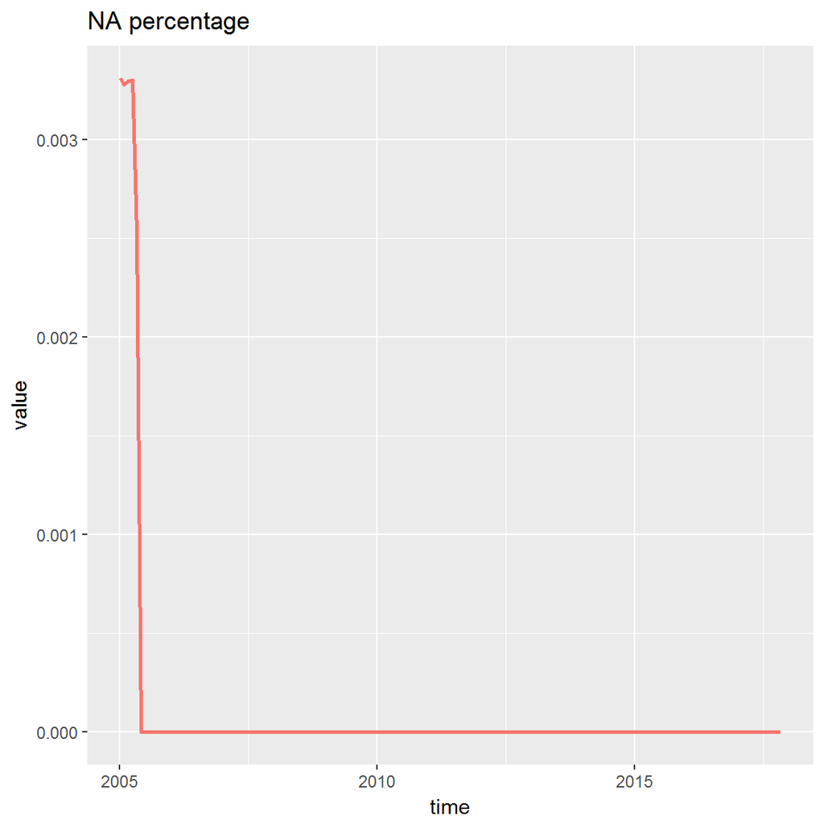

```r
chart.Fct_NA(tsfr)
```

因子原始得分直方图

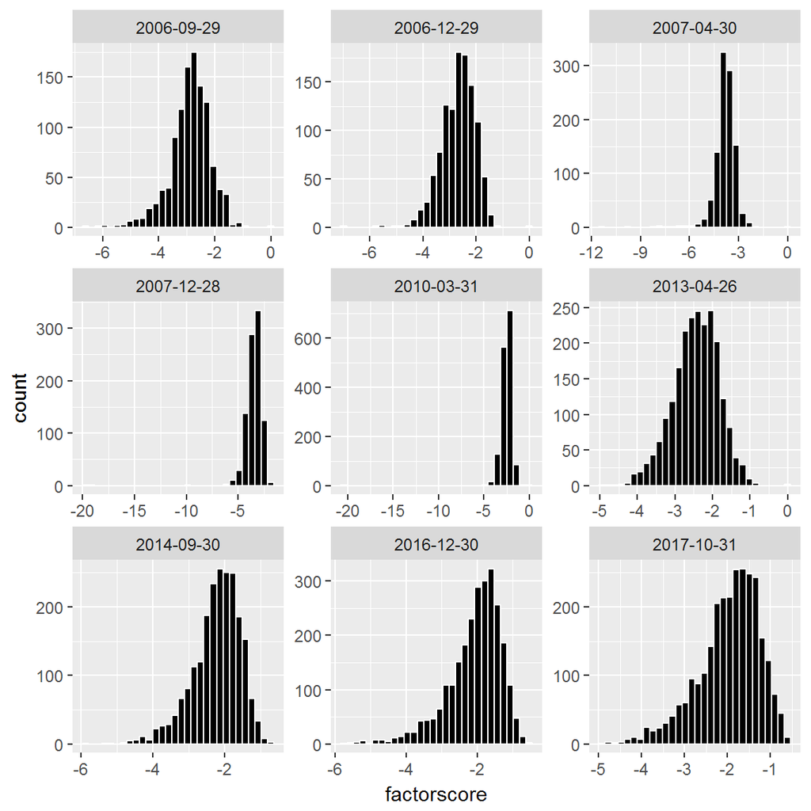

```r
chart.Fct_hist(tsfr,9)
```

不同refine方式下因子得分分布直方图

```
## The guessed factorNames are: scale,scale_ind,scale_indfct,reg_indfct.
```

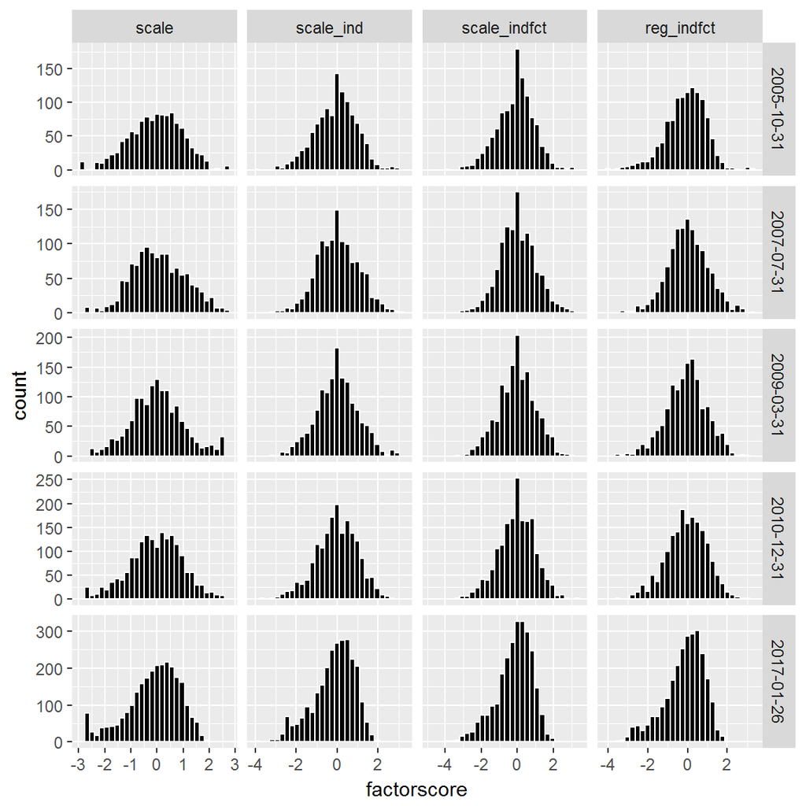

```r
MF.chart.Fct_hist(mtsfr,5)
```

不同refine方式下因子得分统计表

```r
kable(MF.table.Fct_descr(mtsfr,5),digits = 2)
```

```
## The guessed factorNames are: scale,scale_ind,scale_indfct,reg_indfct.
```

| date | fname | Obs | NAs | min | max | mean | median | sd | skewness | kurtosis |
| --- | --- | --- | --- | --- | --- | --- | --- | --- | --- | --- |
| 2005-06-30 | scale | 1208 | 0 | -2.68 | 2.48 | -0.06 | 0 | 1.00 | -0.19 | -0.06 |
| 2005-06-30 | scale_ind | 1208 | 0 | -3.43 | 3.11 | -0.08 | 0 | 0.99 | -0.20 | 0.24 |
| 2005-06-30 | scale_indfct | 1208 | 0 | -3.49 | 2.99 | -0.08 | 0 | 0.99 | -0.25 | 0.19 |
| 2005-06-30 | reg_indfct | 1208 | 0 | -3.26 | 2.84 | -0.08 | 0 | 1.00 | -0.21 | 0.29 |
| 2006-02-28 | scale | 1058 | 0 | -2.55 | 2.43 | -0.10 | 0 | 1.00 | -0.49 | 0.11 |
| 2006-02-28 | scale_ind | 1058 | 0 | -3.09 | 2.95 | -0.06 | 0 | 0.99 | -0.40 | 0.05 |
| 2006-02-28 | scale_indfct | 1058 | 0 | -3.09 | 2.95 | -0.06 | 0 | 0.99 | -0.37 | 0.04 |
| 2006-02-28 | reg_indfct | 1058 | 0 | -3.10 | 3.14 | -0.06 | 0 | 1.00 | -0.42 | 0.12 |
| 2009-06-30 | scale | 1400 | 0 | -2.59 | 2.64 | -0.01 | 0 | 1.00 | -0.17 | -0.03 |
| 2009-06-30 | scale_ind | 1400 | 0 | -3.16 | 3.53 | -0.04 | 0 | 1.00 | -0.24 | 0.07 |
| 2009-06-30 | scale_indfct | 1400 | 0 | -3.31 | 3.53 | -0.06 | 0 | 0.99 | -0.32 | 0.07 |
| 2009-06-30 | reg_indfct | 1400 | 0 | -3.61 | 3.01 | -0.08 | 0 | 1.00 | -0.39 | 0.21 |
| 2015-02-27 | scale | 2136 | 0 | -2.68 | 2.18 | -0.12 | 0 | 1.00 | -0.54 | -0.11 |
| 2015-02-27 | scale_ind | 2136 | 0 | -3.56 | 4.11 | -0.09 | 0 | 1.00 | -0.50 | 0.23 |
| 2015-02-27 | scale_indfct | 2136 | 0 | -4.27 | 4.11 | -0.10 | 0 | 0.99 | -0.41 | 0.16 |
| 2015-02-27 | reg_indfct | 2136 | 0 | -3.50 | 2.47 | -0.10 | 0 | 1.00 | -0.55 | 0.23 |
| 2017-09-29 | scale | 2750 | 0 | -2.72 | 2.07 | -0.11 | 0 | 1.00 | -0.53 | -0.11 |
| 2017-09-29 | scale_ind | 2750 | 0 | -4.03 | 2.34 | -0.11 | 0 | 1.00 | -0.52 | 0.22 |
| 2017-09-29 | scale_indfct | 2750 | 0 | -4.03 | 2.78 | -0.12 | 0 | 0.99 | -0.53 | 0.25 |
| 2017-09-29 | reg_indfct | 2750 | 0 | -3.77 | 2.56 | -0.13 | 0 | 1.00 | -0.52 | 0.17 |

不同refine方式下因子IC图

```
## The guessed factorNames are: scale,scale_ind,scale_indfct,reg_indfct.
```

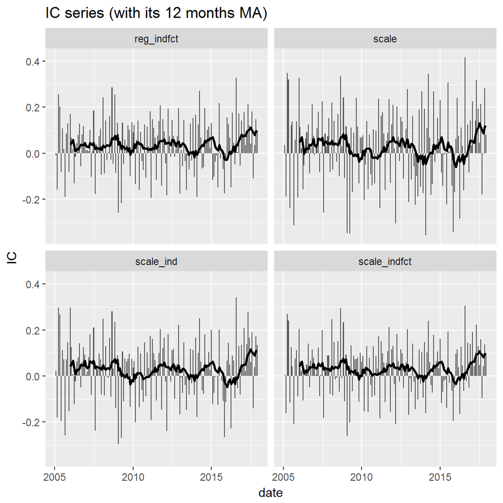

```r
MF.chart.IC(mTSFR = mtsfr,facet_by = 'fname')
```

不同refine方式下因子分组多空收益图

```
## The guessed factorNames are: scale,scale_ind,scale_indfct,reg_indfct.
```

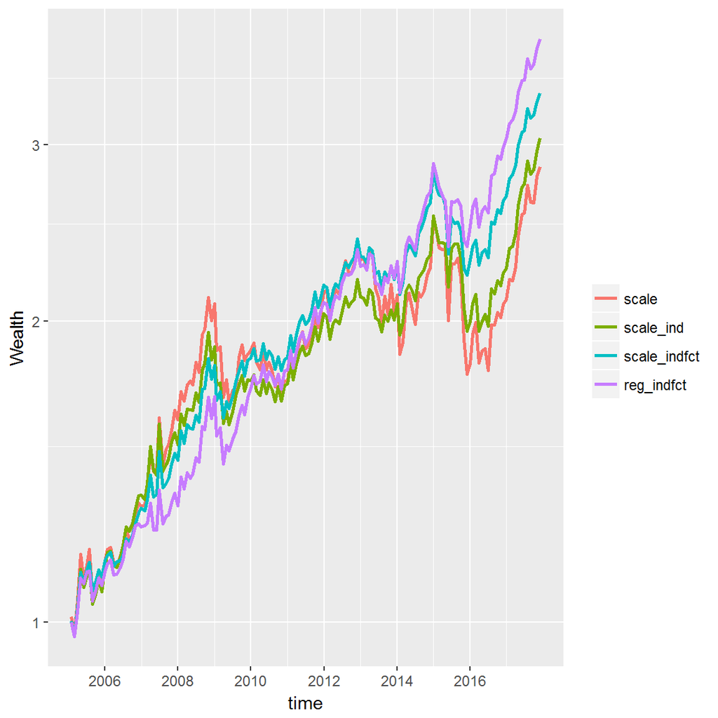

```r
MF.chart.Ngroup.spread(mTSFR = mtsfr, N = 5)
```

不同refine方式下因子分组多空相对收益图

```
## The guessed factorNames are: scale,scale_ind,scale_indfct,reg_indfct.
```

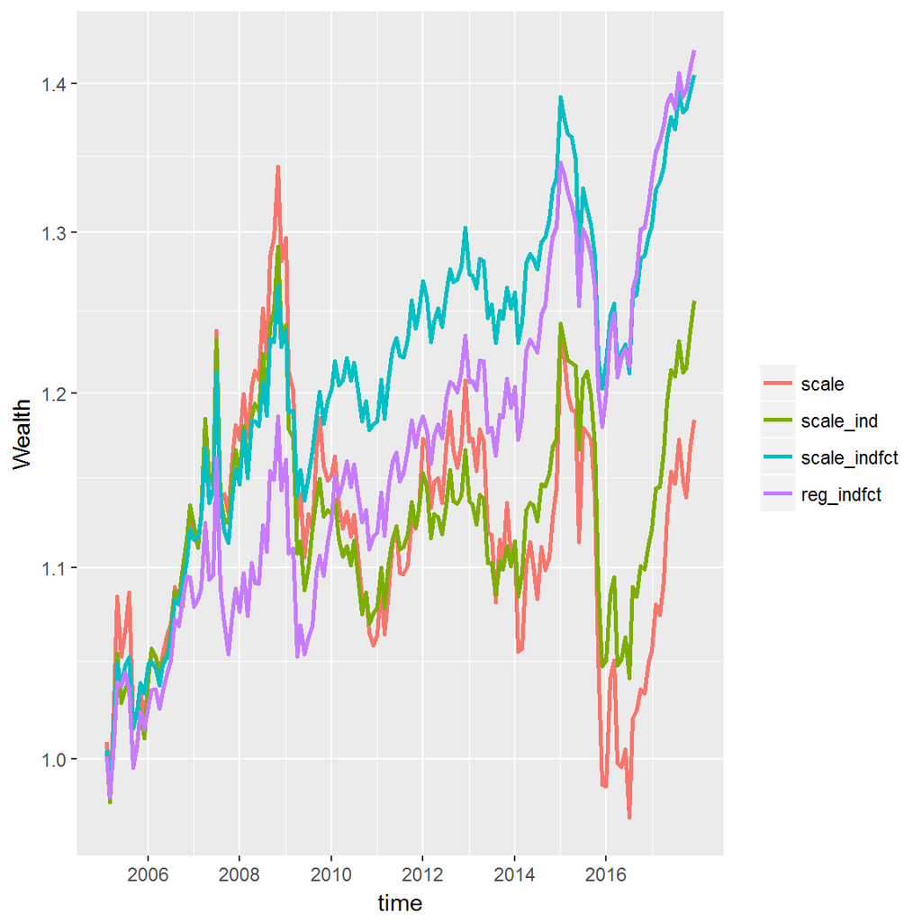

```r
MF.chart.Ngroup.spread(mTSFR = mtsfr, N = 5,rtn_type = "long-univ")
```

不同refine方式下因子IC和分组收益统计表

```r
table_ <- MC.table.ICandNgroup(mTSF2TSFs(mtsfr), N = 5)
```

```
## The guessed factorNames are: scale,scale_ind,scale_indfct,reg_indfct.
```

```r
kable(table_,digits = 2)
```

|  | IC_mean | IC_std | IC_IR | IC_t | IC_p | IC_hitRatio | IC_annu | Annualized Return | Annualized StdDev | Annualized Sharpe(Rf=0%) | HitRatio | Worst Drawdown | Annualized Turnover | Annualized Return (fee cut) | Beta | Size |
| --- | --- | --- | --- | --- | --- | --- | --- | --- | --- | --- | --- | --- | --- | --- | --- | --- |
| scale | 0.03 | 0.17 | 0.18 | 2.23 | 0.03 | 0.63 | 0.10 | 0.08 | 0.18 | 0.48 | 0.63 | 0.30 | 3.79 | 0.08 | -0.28 | 263.36 |
| scale_ind | 0.03 | 0.13 | 0.23 | 2.88 | 0.00 | 0.62 | 0.11 | 0.09 | 0.14 | 0.64 | 0.62 | 0.23 | 4.03 | 0.09 | -0.23 | 200.99 |
| scale_indfct | 0.03 | 0.12 | 0.28 | 3.50 | 0.00 | 0.64 | 0.11 | 0.10 | 0.12 | 0.80 | 0.64 | 0.21 | 4.27 | 0.10 | -0.20 | 178.62 |
| reg_indfct | 0.04 | 0.12 | 0.31 | 3.90 | 0.00 | 0.64 | 0.13 | 0.11 | 0.13 | 0.86 | 0.63 | 0.17 | 4.02 | 0.11 | -0.21 | 72.76 |

```r
table_ <- data.frame(factorName="VOL_",refinePar=rownames(table_),table_,row.names = NULL,stringsAsFactors = FALSE)
tablestats <- rbind(tablestats,table_)
```

## 2、特异度因子IVR

```r
tsfr <- tsfrs_raw$IVR_
mtsfr <- factor_refine_MF(tsfr,refinePars)
```

```
## Function getTSF: getting the factorscore ....
## Function getTSF: getting the factorscore ....
## Function getMultiFactor: getting the score of factor ln_cap ....
```

```r
mtsfrrefine <- rbind(mtsfrrefine,data.frame(mtsfr,fname='IVR_'))
```

因子NA比例

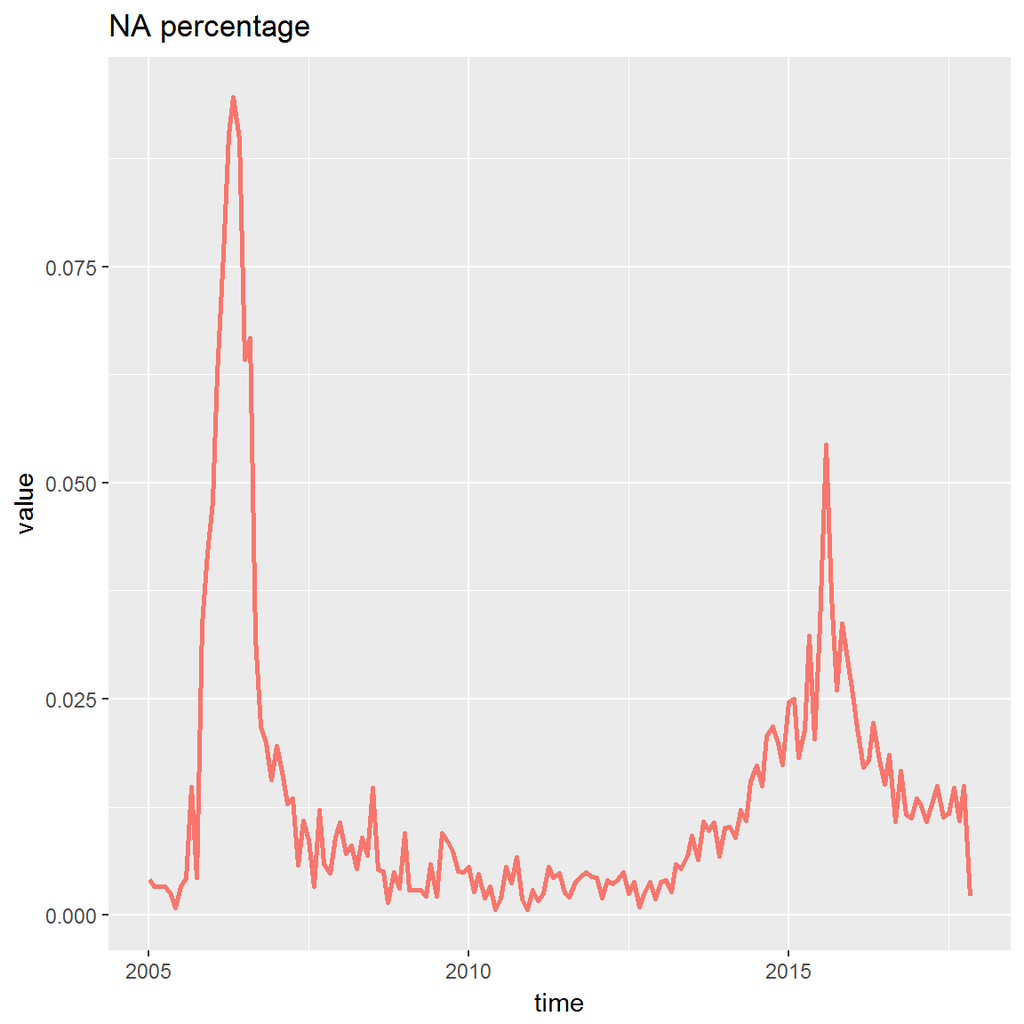

```r
chart.Fct_NA(tsfr)
```

因子原始得分直方图

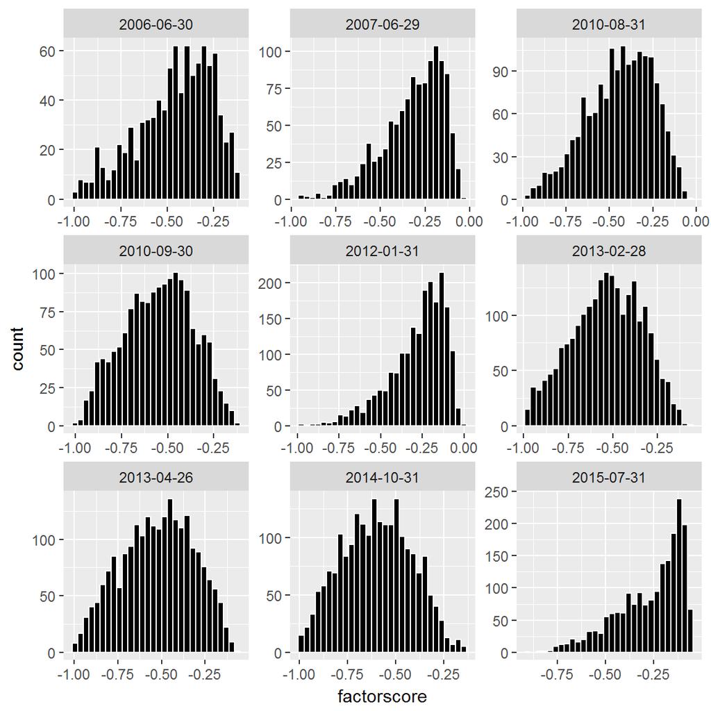

```r
chart.Fct_hist(tsfr,9)
```

不同refine方式下因子得分分布直方图

```
## The guessed factorNames are: scale,scale_ind,scale_indfct,reg_indfct.
```

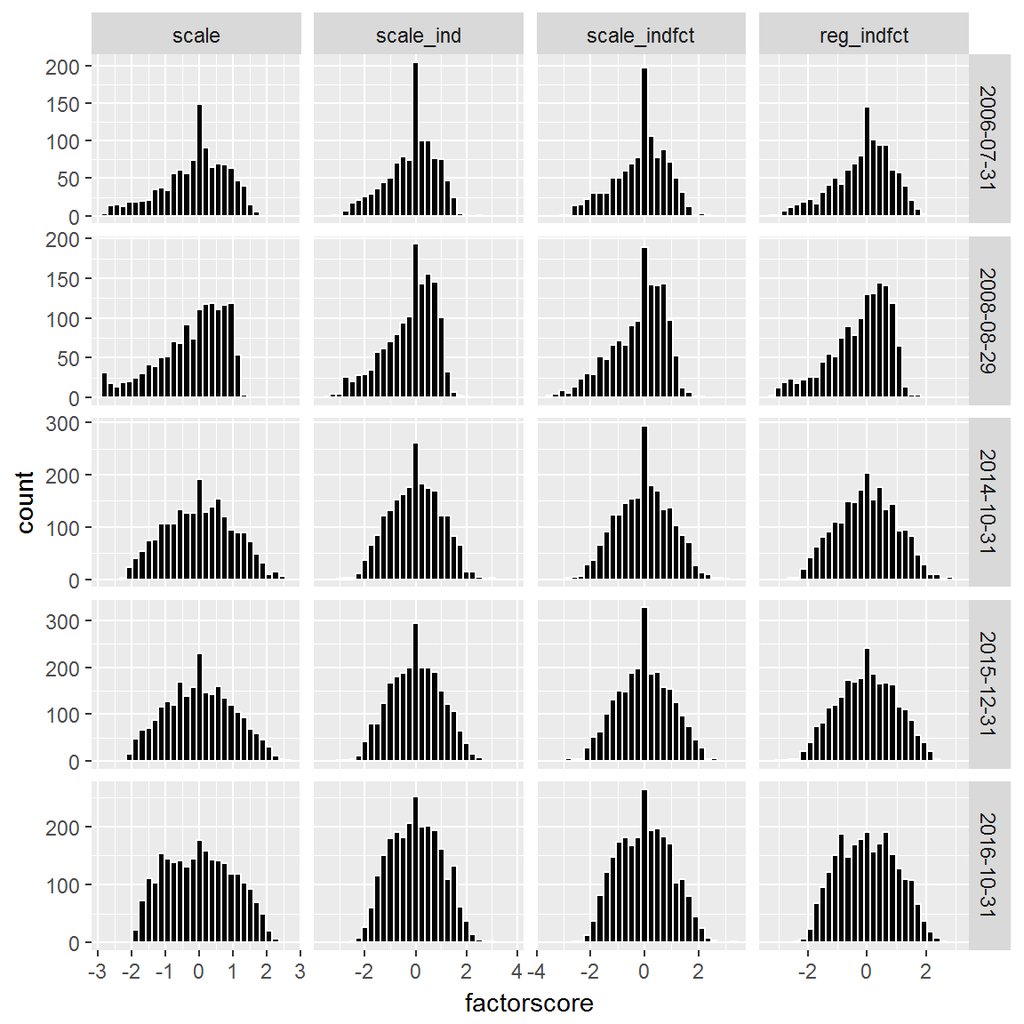

```r
MF.chart.Fct_hist(mtsfr,5)
```

不同refine方式下因子得分统计表

```r
kable(MF.table.Fct_descr(mtsfr,5),digits = 2)
```

```
## The guessed factorNames are: scale,scale_ind,scale_indfct,reg_indfct.
```

| date | fname | Obs | NAs | min | max | mean | median | sd | skewness | kurtosis |
| --- | --- | --- | --- | --- | --- | --- | --- | --- | --- | --- |
| 2006-09-29 | scale | 1102 | 0 | -1.98 | 2.79 | 0.02 | 0.00 | 0.99 | 0.13 | -0.71 |
| 2006-09-29 | scale_ind | 1102 | 0 | -3.29 | 2.96 | 0.01 | 0.00 | 0.99 | 0.09 | -0.39 |
| 2006-09-29 | scale_indfct | 1102 | 0 | -3.29 | 2.81 | -0.02 | 0.00 | 0.98 | 0.07 | -0.36 |
| 2006-09-29 | reg_indfct | 1102 | 0 | -2.88 | 2.94 | 0.03 | -0.01 | 0.99 | 0.10 | -0.59 |
| 2009-03-31 | scale | 1403 | 0 | -2.72 | 1.68 | -0.14 | 0.00 | 1.00 | -0.63 | -0.19 |
| 2009-03-31 | scale_ind | 1403 | 0 | -3.39 | 1.89 | -0.14 | 0.00 | 0.99 | -0.64 | 0.02 |
| 2009-03-31 | scale_indfct | 1403 | 0 | -3.55 | 2.36 | -0.13 | 0.00 | 0.99 | -0.60 | 0.08 |
| 2009-03-31 | reg_indfct | 1403 | 0 | -2.97 | 1.90 | -0.15 | 0.00 | 1.00 | -0.63 | -0.10 |
| 2012-10-31 | scale | 2107 | 0 | -2.79 | 1.80 | -0.14 | 0.00 | 1.00 | -0.42 | -0.61 |
| 2012-10-31 | scale_ind | 2107 | 0 | -3.29 | 2.51 | -0.13 | 0.00 | 1.00 | -0.40 | -0.42 |
| 2012-10-31 | scale_indfct | 2107 | 0 | -3.29 | 2.81 | -0.11 | 0.00 | 0.99 | -0.39 | -0.31 |
| 2012-10-31 | reg_indfct | 2107 | 0 | -3.38 | 2.10 | -0.15 | 0.00 | 1.00 | -0.42 | -0.47 |
| 2014-06-30 | scale | 2201 | 0 | -2.19 | 2.37 | -0.01 | 0.00 | 0.99 | -0.03 | -0.71 |
| 2014-06-30 | scale_ind | 2201 | 0 | -3.04 | 2.56 | -0.04 | 0.00 | 0.99 | -0.10 | -0.61 |
| 2014-06-30 | scale_indfct | 2201 | 0 | -3.04 | 2.47 | -0.03 | 0.00 | 0.99 | -0.10 | -0.49 |
| 2014-06-30 | reg_indfct | 2201 | 0 | -3.39 | 2.57 | -0.03 | -0.01 | 0.99 | -0.11 | -0.63 |
| 2014-12-31 | scale | 2157 | 0 | -2.91 | 1.91 | -0.09 | 0.00 | 0.99 | -0.39 | -0.48 |
| 2014-12-31 | scale_ind | 2157 | 0 | -3.61 | 2.90 | -0.08 | 0.00 | 0.99 | -0.36 | -0.23 |
| 2014-12-31 | scale_indfct | 2157 | 0 | -3.61 | 2.90 | -0.07 | 0.00 | 0.98 | -0.37 | -0.03 |
| 2014-12-31 | reg_indfct | 2157 | 0 | -3.51 | 2.16 | -0.11 | 0.00 | 0.99 | -0.44 | -0.18 |

不同refine方式下因子IC图

```
## The guessed factorNames are: scale,scale_ind,scale_indfct,reg_indfct.
```

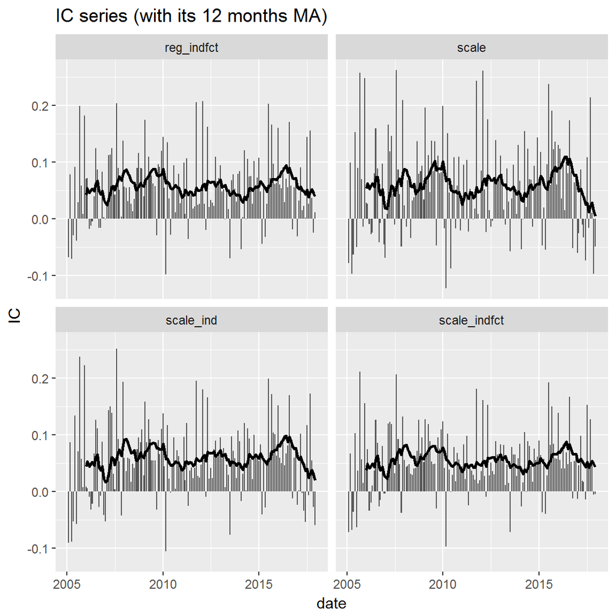

```r
MF.chart.IC(mTSFR = mtsfr,facet_by = 'fname')
```

不同refine方式下因子分组多空收益图

```
## The guessed factorNames are: scale,scale_ind,scale_indfct,reg_indfct.
```

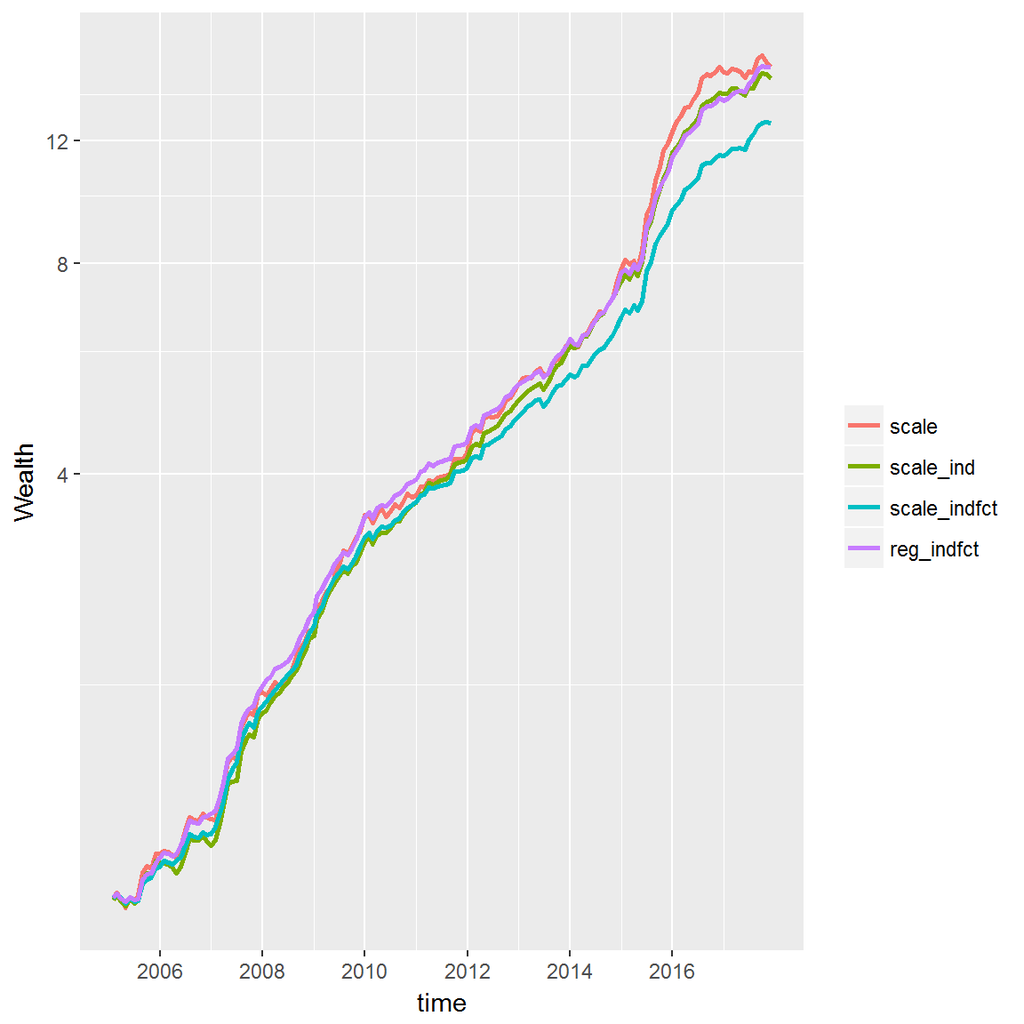

```r
MF.chart.Ngroup.spread(mTSFR = mtsfr, N = 5)
```

不同refine方式下因子分组多空相对收益图

```
## The guessed factorNames are: scale,scale_ind,scale_indfct,reg_indfct.
```

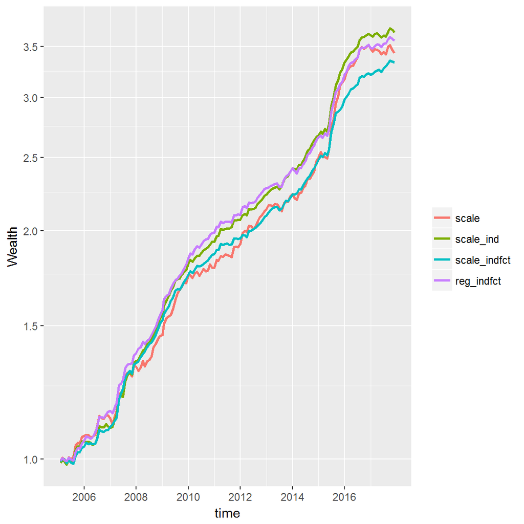

```r
MF.chart.Ngroup.spread(mTSFR = mtsfr, N = 5,rtn_type = "long-univ")
```

不同refine方式下因子IC和分组收益统计表

```r
table_ <- MC.table.ICandNgroup(mTSF2TSFs(mtsfr), N = 5)
```

```
## The guessed factorNames are: scale,scale_ind,scale_indfct,reg_indfct.
```

```r
kable(table_,digits = 2)
```

|  | IC_mean | IC_std | IC_IR | IC_t | IC_p | IC_hitRatio | IC_annu | Annualized Return | Annualized StdDev | Annualized Sharpe(Rf=0%) | HitRatio | Worst Drawdown | Annualized Turnover | Annualized Return (fee cut) | Beta | Size |
| --- | --- | --- | --- | --- | --- | --- | --- | --- | --- | --- | --- | --- | --- | --- | --- | --- |
| scale | 0.06 | 0.08 | 0.70 | 8.74 | 0 | 0.71 | 0.20 | 0.24 | 0.09 | 2.60 | 0.72 | 0.05 | 8.26 | 0.24 | 0.06 | 83.42 |
| scale_ind | 0.06 | 0.07 | 0.86 | 10.69 | 0 | 0.81 | 0.20 | 0.23 | 0.08 | 3.05 | 0.81 | 0.04 | 8.35 | 0.23 | 0.06 | -13.00 |
| scale_indfct | 0.05 | 0.06 | 0.96 | 11.96 | 0 | 0.83 | 0.18 | 0.22 | 0.06 | 3.40 | 0.85 | 0.03 | 8.43 | 0.22 | 0.04 | 1.19 |
| reg_indfct | 0.06 | 0.06 | 0.95 | 11.79 | 0 | 0.85 | 0.19 | 0.24 | 0.07 | 3.41 | 0.86 | 0.03 | 8.36 | 0.24 | 0.04 | 29.88 |

```r
table_ <- data.frame(factorName="IVR_",refinePar=rownames(table_),table_,row.names = NULL,stringsAsFactors = FALSE)
tablestats <- rbind(tablestats,table_)
```

## 3、beta因子

```r
tsfr <- tsfrs_raw$BETA_
mtsfr <- factor_refine_MF(tsfr,refinePars)
```

```
## Function getTSF: getting the factorscore ....
## Function getTSF: getting the factorscore ....
## Function getMultiFactor: getting the score of factor ln_cap ....
```

```r
mtsfrrefine <- rbind(mtsfrrefine,data.frame(mtsfr,fname='BETA_'))
```

因子NA比例

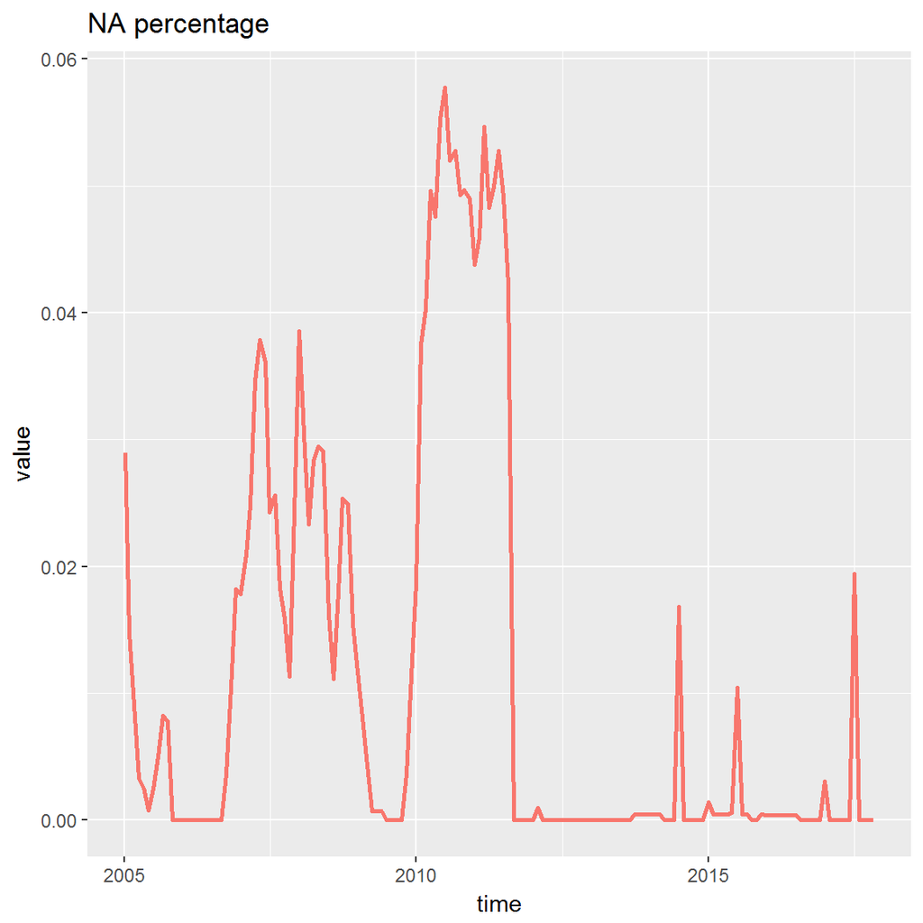

```r
chart.Fct_NA(tsfr)
```

因子原始得分直方图

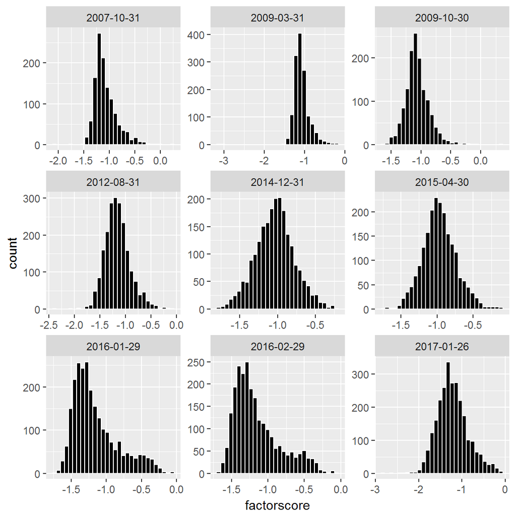

```r
chart.Fct_hist(tsfr,9)
```

不同refine方式下因子得分分布直方图

```
## The guessed factorNames are: scale,scale_ind,scale_indfct,reg_indfct.
```

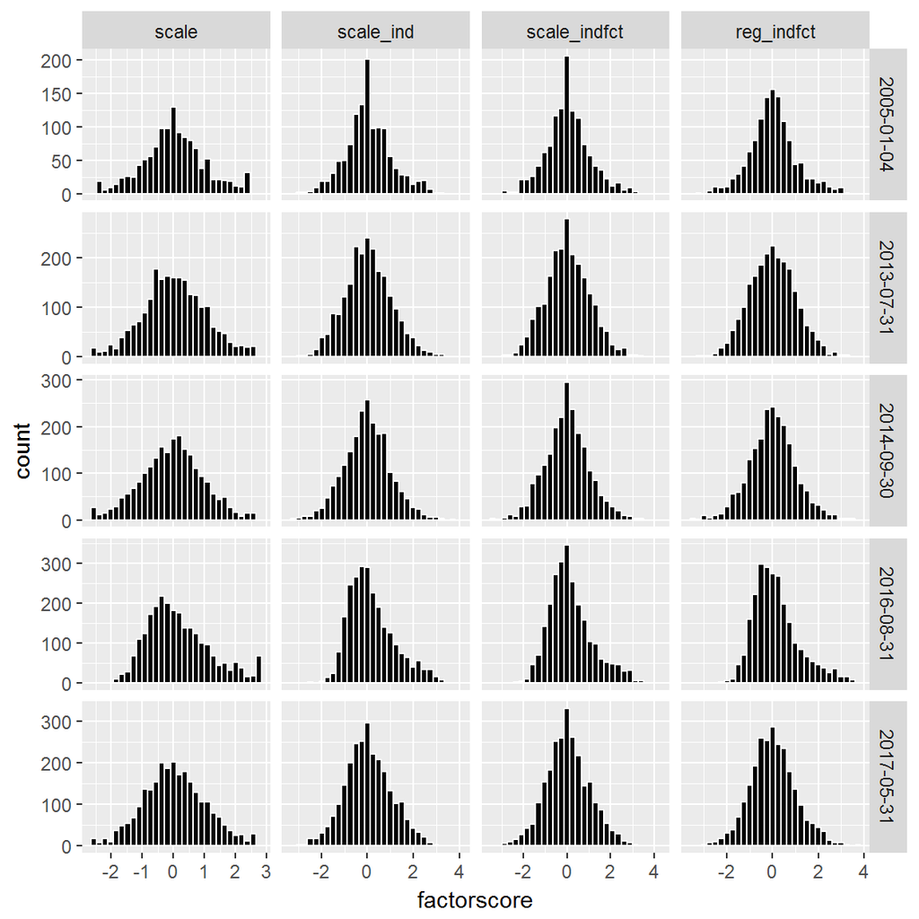

```r
MF.chart.Fct_hist(mtsfr,5)
```

不同refine方式下因子得分统计表

```r
kable(MF.table.Fct_descr(mtsfr,5),digits = 2)
```

```
## The guessed factorNames are: scale,scale_ind,scale_indfct,reg_indfct.
```

| date | fname | Obs | NAs | min | max | mean | median | sd | skewness | kurtosis |
| --- | --- | --- | --- | --- | --- | --- | --- | --- | --- | --- |
| 2010-02-26 | scale | 1464 | 0 | -2.32 | 2.40 | 0.04 | 0.00 | 0.98 | 0.11 | 0.22 |
| 2010-02-26 | scale_ind | 1464 | 0 | -2.95 | 4.38 | 0.09 | 0.00 | 0.98 | 0.49 | 0.81 |
| 2010-02-26 | scale_indfct | 1464 | 0 | -2.95 | 4.38 | 0.09 | 0.00 | 0.97 | 0.46 | 0.87 |
| 2010-02-26 | reg_indfct | 1464 | 0 | -3.36 | 3.87 | 0.09 | 0.02 | 0.98 | 0.47 | 0.83 |
| 2010-06-30 | scale | 1594 | 0 | -2.34 | 2.42 | 0.06 | 0.00 | 0.97 | 0.17 | 0.23 |
| 2010-06-30 | scale_ind | 1594 | 0 | -3.22 | 3.72 | 0.09 | 0.00 | 0.97 | 0.35 | 0.52 |
| 2010-06-30 | scale_indfct | 1594 | 0 | -3.42 | 3.57 | 0.09 | 0.00 | 0.96 | 0.27 | 0.59 |
| 2010-06-30 | reg_indfct | 1594 | 0 | -3.64 | 3.54 | 0.09 | -0.01 | 0.97 | 0.32 | 0.55 |
| 2014-05-30 | scale | 2197 | 0 | -2.74 | 2.76 | 0.02 | 0.00 | 1.00 | 0.13 | -0.14 |
| 2014-05-30 | scale_ind | 2197 | 0 | -3.40 | 3.78 | 0.02 | 0.00 | 1.00 | 0.19 | 0.21 |
| 2014-05-30 | scale_indfct | 2197 | 0 | -3.11 | 3.33 | 0.02 | 0.00 | 1.00 | 0.14 | 0.15 |
| 2014-05-30 | reg_indfct | 2197 | 0 | -3.28 | 3.41 | 0.01 | 0.00 | 1.00 | 0.15 | 0.17 |
| 2015-05-29 | scale | 1715 | 0 | -2.43 | 2.62 | 0.07 | 0.00 | 1.00 | 0.28 | -0.09 |
| 2015-05-29 | scale_ind | 1715 | 0 | -2.89 | 3.32 | 0.12 | 0.00 | 0.99 | 0.43 | 0.14 |
| 2015-05-29 | scale_indfct | 1715 | 0 | -2.56 | 3.32 | 0.12 | 0.00 | 0.99 | 0.41 | 0.03 |
| 2015-05-29 | reg_indfct | 1715 | 0 | -2.50 | 3.38 | 0.11 | 0.00 | 1.00 | 0.46 | 0.17 |
| 2016-09-30 | scale | 2461 | 0 | -2.10 | 2.48 | 0.15 | 0.00 | 1.00 | 0.67 | 0.00 |
| 2016-09-30 | scale_ind | 2461 | 0 | -3.41 | 4.41 | 0.17 | 0.00 | 1.00 | 0.81 | 0.53 |
| 2016-09-30 | scale_indfct | 2461 | 0 | -3.41 | 4.41 | 0.15 | 0.00 | 1.00 | 0.78 | 0.80 |
| 2016-09-30 | reg_indfct | 2461 | 0 | -2.17 | 3.98 | 0.15 | 0.00 | 1.00 | 0.98 | 1.02 |

不同refine方式下因子IC图

```
## The guessed factorNames are: scale,scale_ind,scale_indfct,reg_indfct.
```

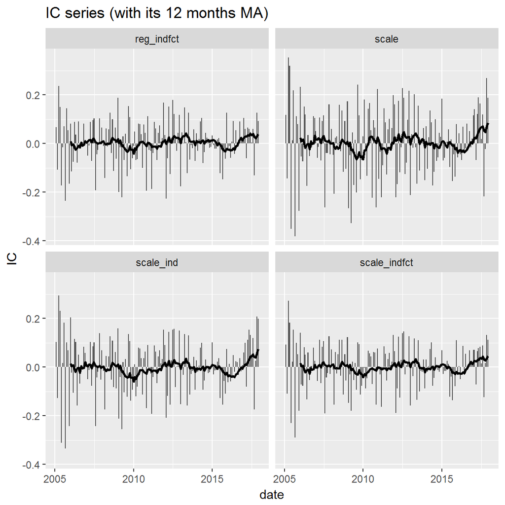

```r
MF.chart.IC(mTSFR = mtsfr,facet_by = 'fname')
```

不同refine方式下因子分组多空收益图

```
## The guessed factorNames are: scale,scale_ind,scale_indfct,reg_indfct.
```

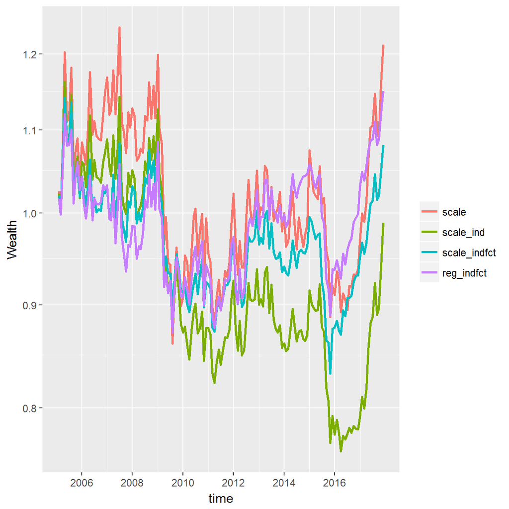

```r
MF.chart.Ngroup.spread(mTSFR = mtsfr, N = 5)
```

不同refine方式下因子分组多空相对收益图

```
## The guessed factorNames are: scale,scale_ind,scale_indfct,reg_indfct.
```

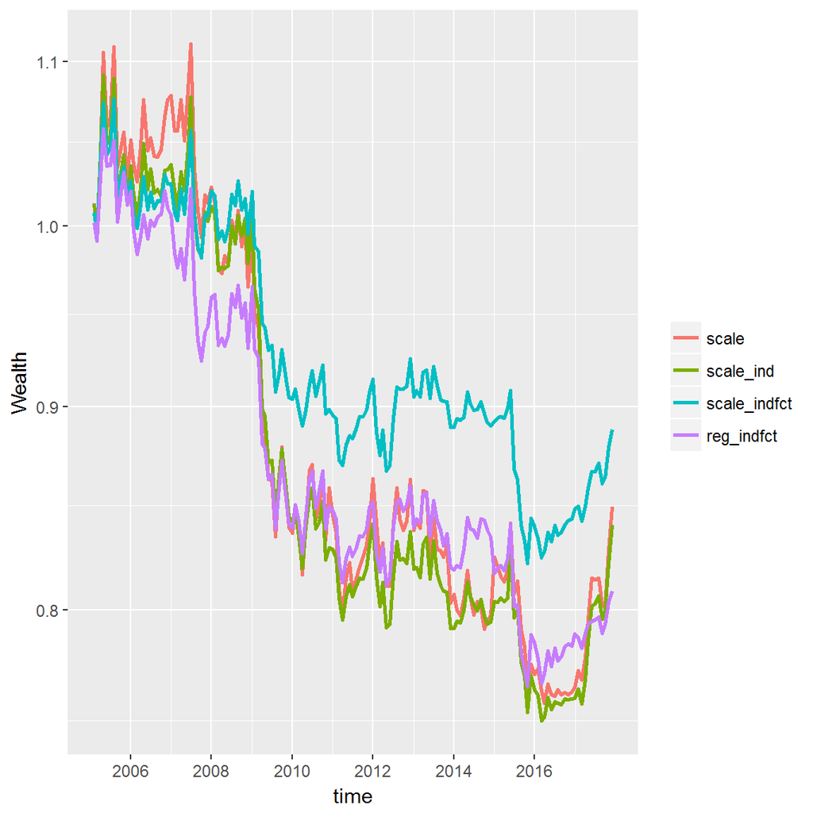

```r
MF.chart.Ngroup.spread(mTSFR = mtsfr, N = 5,rtn_type = "long-univ")
```

不同refine方式下因子IC和分组收益统计表

```r
table_ <- MC.table.ICandNgroup(mTSF2TSFs(mtsfr), N = 5)
```

```
## The guessed factorNames are: scale,scale_ind,scale_indfct,reg_indfct.
```

```r
kable(table_,digits = 2)
```

|  | IC_mean | IC_std | IC_IR | IC_t | IC_p | IC_hitRatio | IC_annu | Annualized Return | Annualized StdDev | Annualized Sharpe(Rf=0%) | HitRatio | Worst Drawdown | Annualized Turnover | Annualized Return (fee cut) | Beta | Size |
| --- | --- | --- | --- | --- | --- | --- | --- | --- | --- | --- | --- | --- | --- | --- | --- | --- |
| scale | 0.01 | 0.14 | 0.05 | 0.58 | 0.56 | 0.54 | 0.02 | 0.02 | 0.14 | 0.11 | 0.52 | 0.30 | 2.23 | 0.02 | -0.19 | 229.42 |
| scale_ind | 0.00 | 0.11 | 0.01 | 0.13 | 0.89 | 0.54 | 0.00 | 0.00 | 0.12 | -0.01 | 0.52 | 0.35 | 2.42 | 0.00 | -0.16 | 211.82 |
| scale_indfct | 0.00 | 0.09 | 0.04 | 0.47 | 0.64 | 0.56 | 0.01 | 0.01 | 0.10 | 0.06 | 0.55 | 0.27 | 2.73 | 0.01 | -0.13 | 182.80 |
| reg_indfct | 0.00 | 0.09 | 0.05 | 0.67 | 0.50 | 0.57 | 0.02 | 0.01 | 0.10 | 0.11 | 0.55 | 0.22 | 2.39 | 0.01 | -0.14 | 95.77 |

```r
table_ <- data.frame(factorName="BETA_",refinePar=rownames(table_),table_,row.names = NULL,stringsAsFactors = FALSE)
tablestats <- rbind(tablestats,table_)
```

## 4、流动性因子LIQ

```r
tsfr <- tsfrs_raw$liquidity_
mtsfr <- factor_refine_MF(tsfr,refinePars)
```

```
## Function getTSF: getting the factorscore ....
## Function getTSF: getting the factorscore ....
## Function getMultiFactor: getting the score of factor ln_cap ....
```

```r
mtsfrrefine <- rbind(mtsfrrefine,data.frame(mtsfr,fname='liquidity_'))
```

因子NA比例

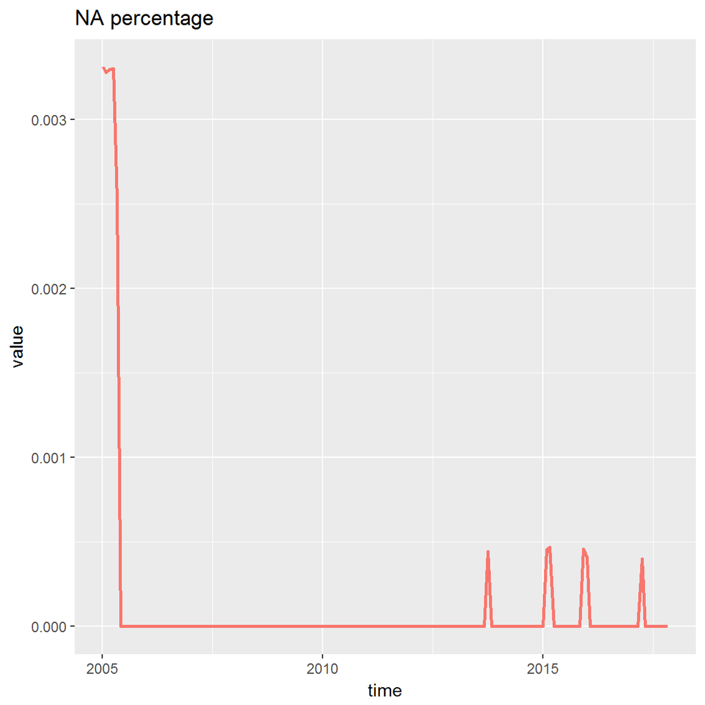

```r
chart.Fct_NA(tsfr)
```

因子原始得分直方图

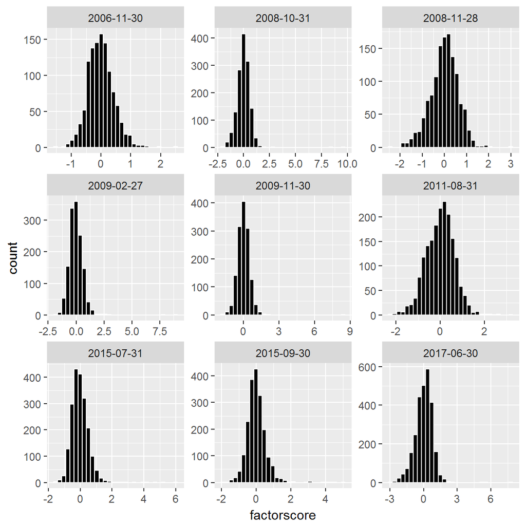

```r
chart.Fct_hist(tsfr,9)
```

不同refine方式下因子得分分布直方图

```
## The guessed factorNames are: scale,scale_ind,scale_indfct,reg_indfct.
```

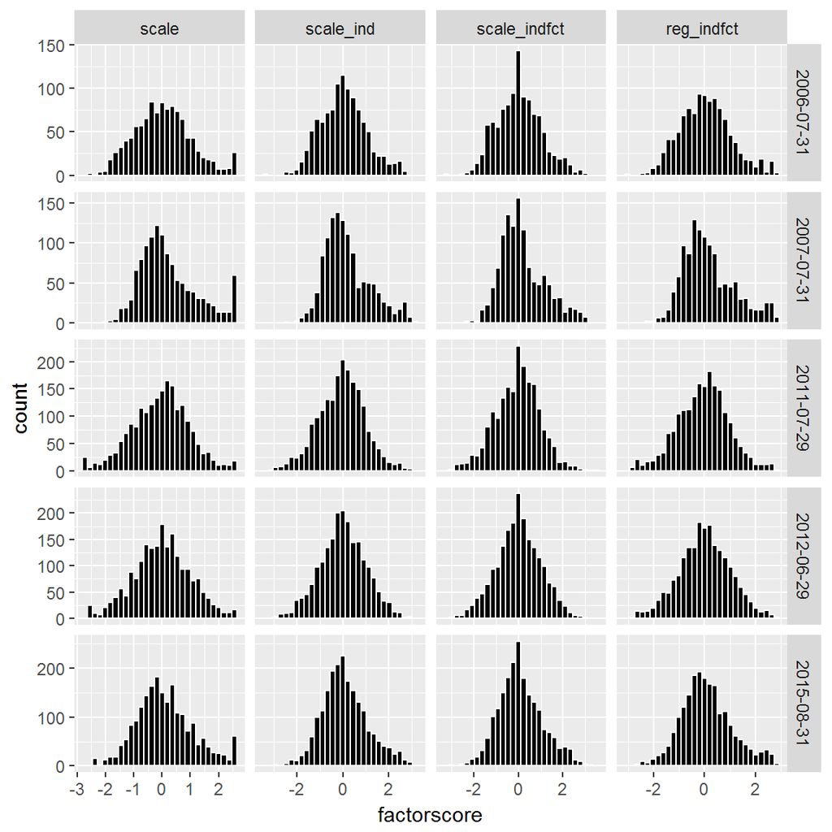

```r
MF.chart.Fct_hist(mtsfr,5)
```

不同refine方式下因子得分统计表

```r
kable(MF.table.Fct_descr(mtsfr,5),digits = 2)
```

```
## The guessed factorNames are: scale,scale_ind,scale_indfct,reg_indfct.
```

| date | fname | Obs | NAs | min | max | mean | median | sd | skewness | kurtosis |
| --- | --- | --- | --- | --- | --- | --- | --- | --- | --- | --- |
| 2005-01-04 | scale | 1209 | 0 | -2.61 | 2.55 | -0.03 | 0 | 1.00 | -0.16 | -0.14 |
| 2005-01-04 | scale_ind | 1209 | 0 | -3.20 | 2.90 | 0.00 | 0 | 0.99 | -0.16 | -0.02 |
| 2005-01-04 | scale_indfct | 1209 | 0 | -3.06 | 3.06 | -0.02 | 0 | 0.99 | -0.17 | 0.05 |
| 2005-01-04 | reg_indfct | 1209 | 0 | -2.93 | 2.83 | -0.01 | 0 | 1.00 | -0.14 | -0.02 |
| 2006-08-31 | scale | 1122 | 0 | -2.32 | 2.77 | 0.07 | 0 | 1.00 | 0.37 | -0.07 |
| 2006-08-31 | scale_ind | 1122 | 0 | -2.28 | 3.27 | 0.06 | 0 | 1.00 | 0.37 | 0.07 |
| 2006-08-31 | scale_indfct | 1122 | 0 | -2.34 | 3.24 | 0.06 | 0 | 1.00 | 0.30 | -0.01 |
| 2006-08-31 | reg_indfct | 1122 | 0 | -2.41 | 3.21 | 0.07 | 0 | 1.00 | 0.41 | 0.09 |
| 2006-11-30 | scale | 1153 | 0 | -2.57 | 2.64 | 0.04 | 0 | 1.00 | 0.21 | 0.01 |
| 2006-11-30 | scale_ind | 1153 | 0 | -3.10 | 3.25 | 0.04 | 0 | 1.00 | 0.22 | 0.11 |
| 2006-11-30 | scale_indfct | 1153 | 0 | -3.00 | 3.45 | 0.02 | 0 | 0.99 | 0.23 | 0.17 |
| 2006-11-30 | reg_indfct | 1153 | 0 | -2.85 | 3.04 | 0.05 | 0 | 1.00 | 0.23 | 0.05 |
| 2008-11-28 | scale | 1289 | 0 | -2.60 | 2.45 | -0.07 | 0 | 1.00 | -0.25 | -0.04 |
| 2008-11-28 | scale_ind | 1289 | 0 | -3.19 | 2.94 | -0.06 | 0 | 0.99 | -0.16 | -0.10 |
| 2008-11-28 | scale_indfct | 1289 | 0 | -3.19 | 2.94 | -0.06 | 0 | 0.99 | -0.14 | -0.11 |
| 2008-11-28 | reg_indfct | 1289 | 0 | -3.30 | 3.08 | -0.06 | 0 | 1.00 | -0.22 | -0.04 |
| 2011-12-30 | scale | 1828 | 0 | -2.56 | 2.70 | 0.00 | 0 | 1.00 | -0.11 | -0.24 |
| 2011-12-30 | scale_ind | 1828 | 0 | -2.97 | 2.71 | -0.02 | 0 | 1.00 | -0.11 | -0.30 |
| 2011-12-30 | scale_indfct | 1828 | 0 | -2.97 | 2.72 | -0.02 | 0 | 1.00 | -0.10 | -0.22 |
| 2011-12-30 | reg_indfct | 1828 | 0 | -2.80 | 2.98 | -0.01 | 0 | 1.00 | -0.11 | -0.23 |

不同refine方式下因子IC图

```
## The guessed factorNames are: scale,scale_ind,scale_indfct,reg_indfct.
```

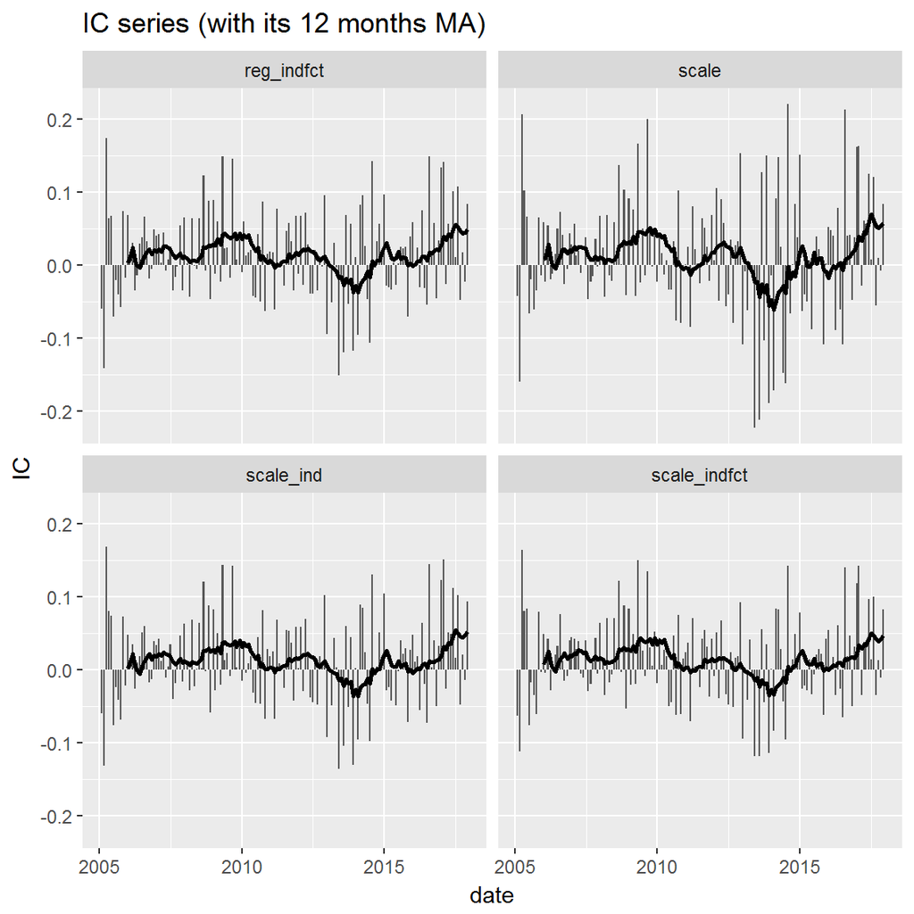

```r
MF.chart.IC(mTSFR = mtsfr,facet_by = 'fname')
```

不同refine方式下因子分组多空收益图

```
## The guessed factorNames are: scale,scale_ind,scale_indfct,reg_indfct.
```

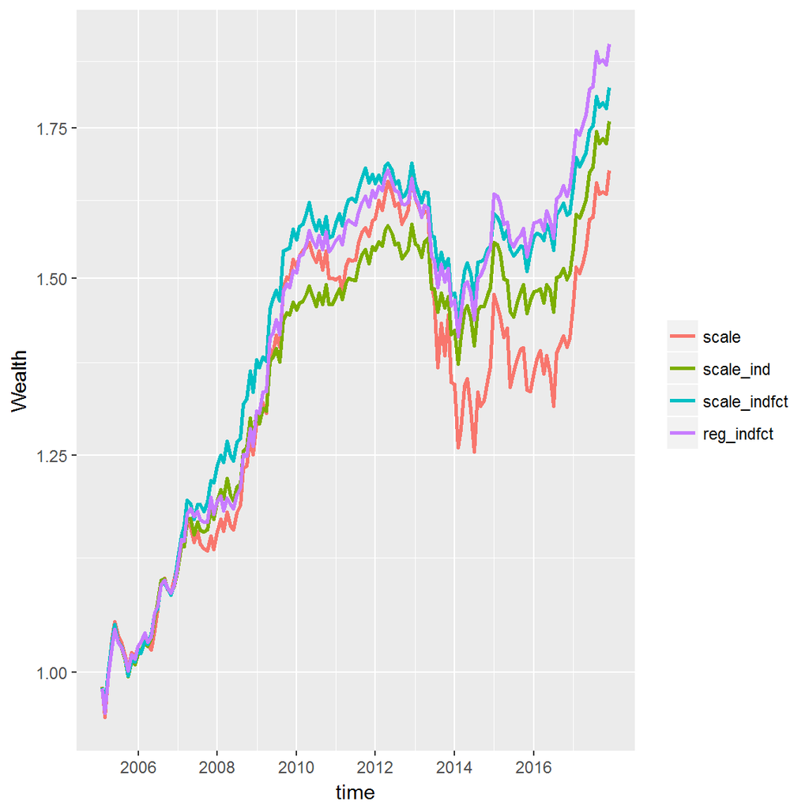

```r
MF.chart.Ngroup.spread(mTSFR = mtsfr, N = 5)
```

不同refine方式下因子分组多空相对收益图

```
## The guessed factorNames are: scale,scale_ind,scale_indfct,reg_indfct.
```

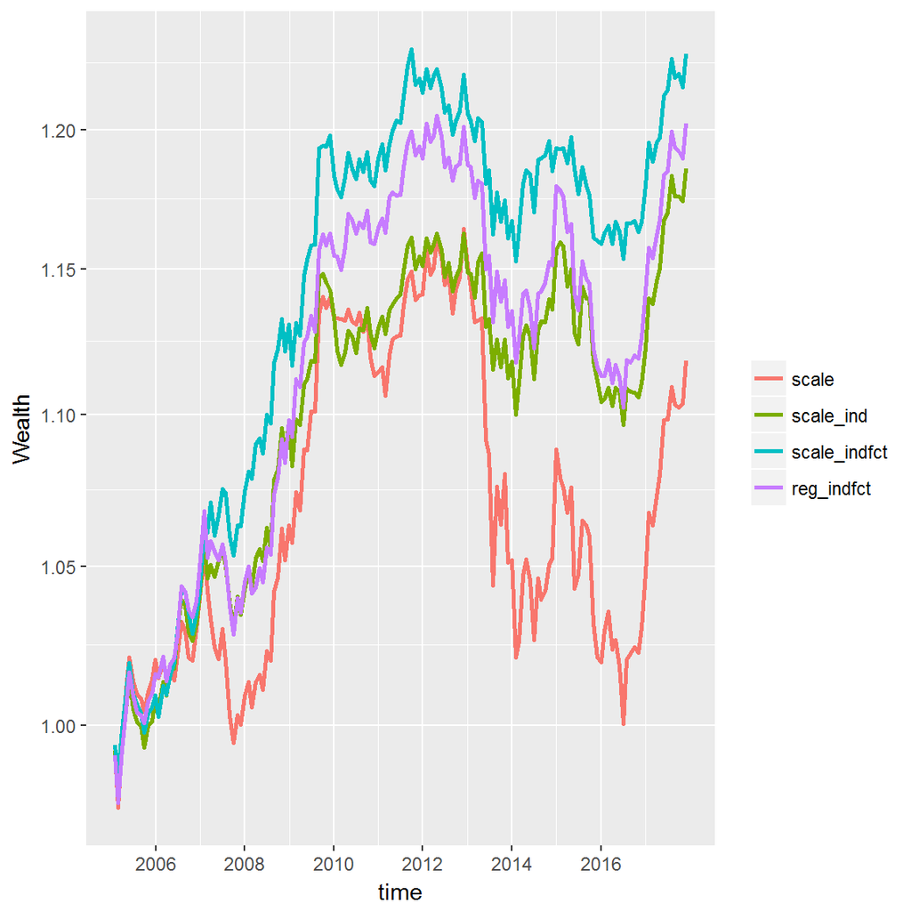

```r
MF.chart.Ngroup.spread(mTSFR = mtsfr, N = 5,rtn_type = "long-univ")
```

不同refine方式下因子IC和分组收益统计表

```r
table_ <- MC.table.ICandNgroup(mTSF2TSFs(mtsfr), N = 5)
```

```
## The guessed factorNames are: scale,scale_ind,scale_indfct,reg_indfct.
```

```r
kable(table_,digits = 2)
```

|  | IC_mean | IC_std | IC_IR | IC_t | IC_p | IC_hitRatio | IC_annu | Annualized Return | Annualized StdDev | Annualized Sharpe(Rf=0%) | HitRatio | Worst Drawdown | Annualized Turnover | Annualized Return (fee cut) | Beta | Size |
| --- | --- | --- | --- | --- | --- | --- | --- | --- | --- | --- | --- | --- | --- | --- | --- | --- |
| scale | 0.01 | 0.08 | 0.16 | 1.97 | 0.05 | 0.57 | 0.04 | 0.04 | 0.08 | 0.48 | 0.56 | 0.25 | 7.63 | 0.04 | -0.08 | 26.93 |
| scale_ind | 0.01 | 0.06 | 0.22 | 2.75 | 0.01 | 0.63 | 0.04 | 0.04 | 0.06 | 0.75 | 0.60 | 0.13 | 7.78 | 0.04 | -0.06 | 14.40 |
| scale_indfct | 0.01 | 0.06 | 0.25 | 3.05 | 0.00 | 0.59 | 0.05 | 0.05 | 0.06 | 0.80 | 0.59 | 0.15 | 7.86 | 0.05 | -0.05 | 8.81 |
| reg_indfct | 0.01 | 0.06 | 0.24 | 2.99 | 0.00 | 0.59 | 0.05 | 0.05 | 0.06 | 0.84 | 0.58 | 0.16 | 7.76 | 0.05 | -0.04 | -9.78 |

```r
table_ <- data.frame(factorName="liquidity_",refinePar=rownames(table_),table_,row.names = NULL,stringsAsFactors = FALSE)
tablestats <- rbind(tablestats,table_)
```

## 5、非流动性因子ILLIQ

```r
tsfr <- tsfrs_raw$ILLIQ
mtsfr <- factor_refine_MF(tsfr,refinePars)
```

```
## Function getTSF: getting the factorscore ....
## Function getTSF: getting the factorscore ....
## Function getMultiFactor: getting the score of factor ln_cap ....
```

```r
mtsfrrefine <- rbind(mtsfrrefine,data.frame(mtsfr,fname='ILLIQ'))
```

因子NA比例

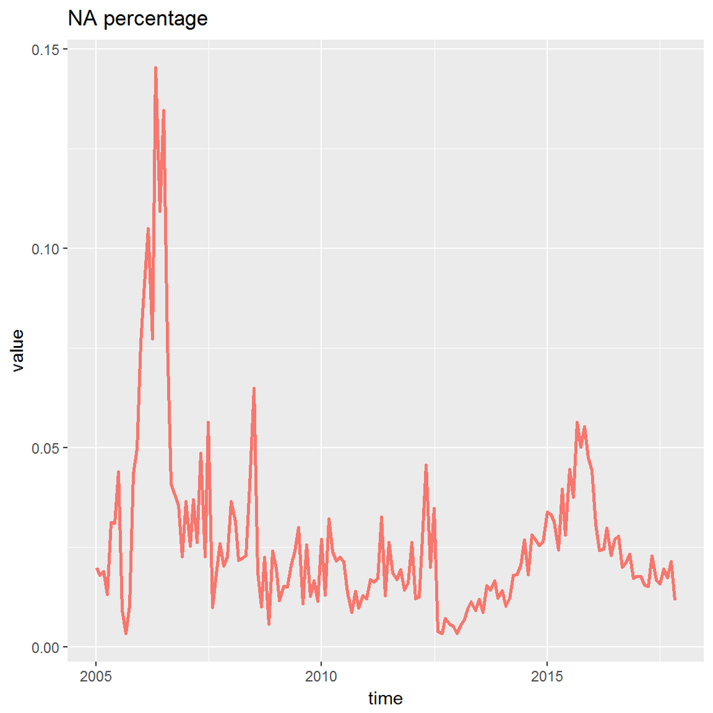

```r
chart.Fct_NA(tsfr)
```

因子原始得分直方图

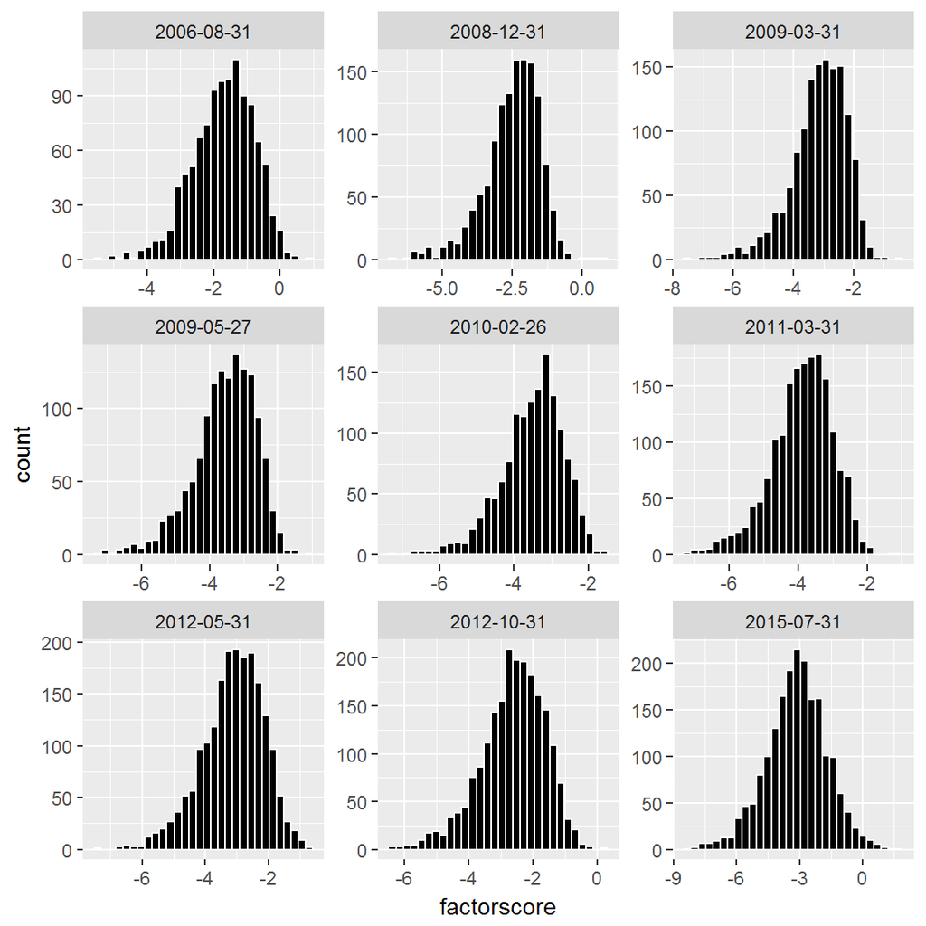

```r
chart.Fct_hist(tsfr,9)
```

不同refine方式下因子得分分布直方图

```
## The guessed factorNames are: scale,scale_ind,scale_indfct,reg_indfct.
```

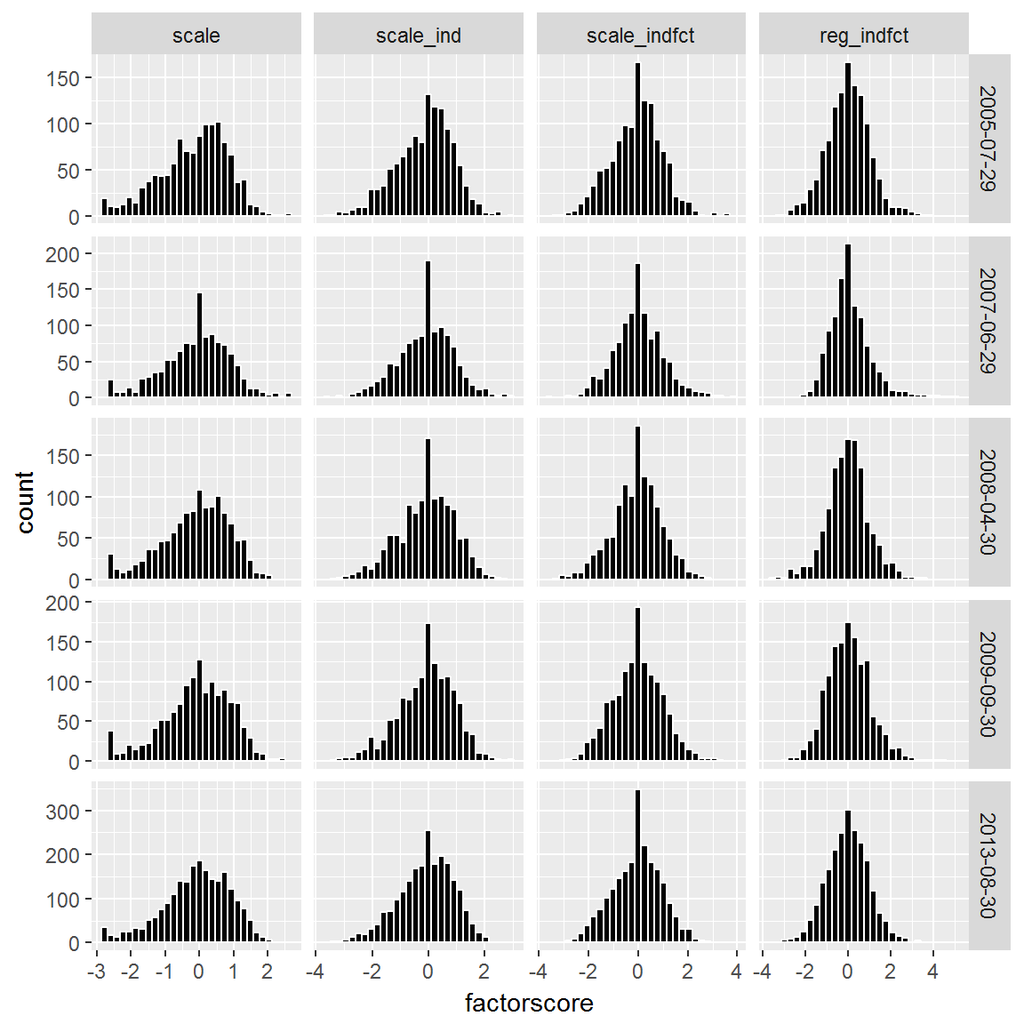

```r
MF.chart.Fct_hist(mtsfr,5)
```

不同refine方式下因子得分统计表

```r
kable(MF.table.Fct_descr(mtsfr,5),digits = 2)
```

```
## The guessed factorNames are: scale,scale_ind,scale_indfct,reg_indfct.
```

| date | fname | Obs | NAs | min | max | mean | median | sd | skewness | kurtosis |
| --- | --- | --- | --- | --- | --- | --- | --- | --- | --- | --- |
| 2005-05-31 | scale | 1228 | 0 | -2.81 | 2.32 | -0.16 | 0 | 0.98 | -0.52 | -0.02 |
| 2005-05-31 | scale_ind | 1228 | 0 | -3.59 | 2.61 | -0.12 | 0 | 0.98 | -0.43 | 0.17 |
| 2005-05-31 | scale_indfct | 1228 | 0 | -3.37 | 3.14 | -0.05 | 0 | 0.98 | -0.09 | 0.04 |
| 2005-05-31 | reg_indfct | 1228 | 0 | -3.44 | 4.66 | 0.00 | 0 | 0.98 | 0.29 | 0.90 |
| 2008-08-29 | scale | 1393 | 0 | -2.85 | 1.97 | -0.15 | 0 | 1.00 | -0.57 | 0.01 |
| 2008-08-29 | scale_ind | 1393 | 0 | -3.72 | 2.79 | -0.10 | 0 | 0.99 | -0.39 | 0.11 |
| 2008-08-29 | scale_indfct | 1393 | 0 | -3.07 | 2.79 | -0.05 | 0 | 0.99 | -0.19 | 0.06 |
| 2008-08-29 | reg_indfct | 1393 | 0 | -4.03 | 3.97 | -0.02 | 0 | 1.00 | -0.03 | 0.68 |
| 2009-04-30 | scale | 1364 | 0 | -2.71 | 2.34 | -0.12 | 0 | 0.99 | -0.56 | 0.07 |
| 2009-04-30 | scale_ind | 1364 | 0 | -3.56 | 3.03 | -0.07 | 0 | 0.99 | -0.35 | 0.28 |
| 2009-04-30 | scale_indfct | 1364 | 0 | -3.02 | 3.59 | 0.02 | 0 | 0.99 | 0.06 | 0.21 |
| 2009-04-30 | reg_indfct | 1364 | 0 | -2.59 | 4.40 | 0.04 | 0 | 0.99 | 0.51 | 0.86 |
| 2009-11-30 | scale | 1401 | 0 | -2.67 | 2.37 | -0.12 | 0 | 0.99 | -0.61 | 0.01 |
| 2009-11-30 | scale_ind | 1401 | 0 | -3.65 | 3.26 | -0.08 | 0 | 0.99 | -0.42 | 0.29 |
| 2009-11-30 | scale_indfct | 1401 | 0 | -3.35 | 3.26 | -0.02 | 0 | 0.99 | -0.11 | 0.15 |
| 2009-11-30 | reg_indfct | 1401 | 0 | -3.06 | 3.91 | 0.05 | 0 | 0.99 | 0.34 | 0.47 |
| 2010-03-31 | scale | 1512 | 0 | -2.73 | 2.57 | -0.13 | 0 | 0.99 | -0.55 | 0.02 |
| 2010-03-31 | scale_ind | 1512 | 0 | -3.60 | 2.78 | -0.08 | 0 | 0.99 | -0.40 | 0.15 |
| 2010-03-31 | scale_indfct | 1512 | 0 | -3.42 | 2.90 | -0.03 | 0 | 0.99 | -0.15 | 0.05 |
| 2010-03-31 | reg_indfct | 1512 | 0 | -3.25 | 3.88 | 0.01 | 0 | 0.99 | 0.09 | 0.51 |

不同refine方式下因子IC图

```
## The guessed factorNames are: scale,scale_ind,scale_indfct,reg_indfct.
```

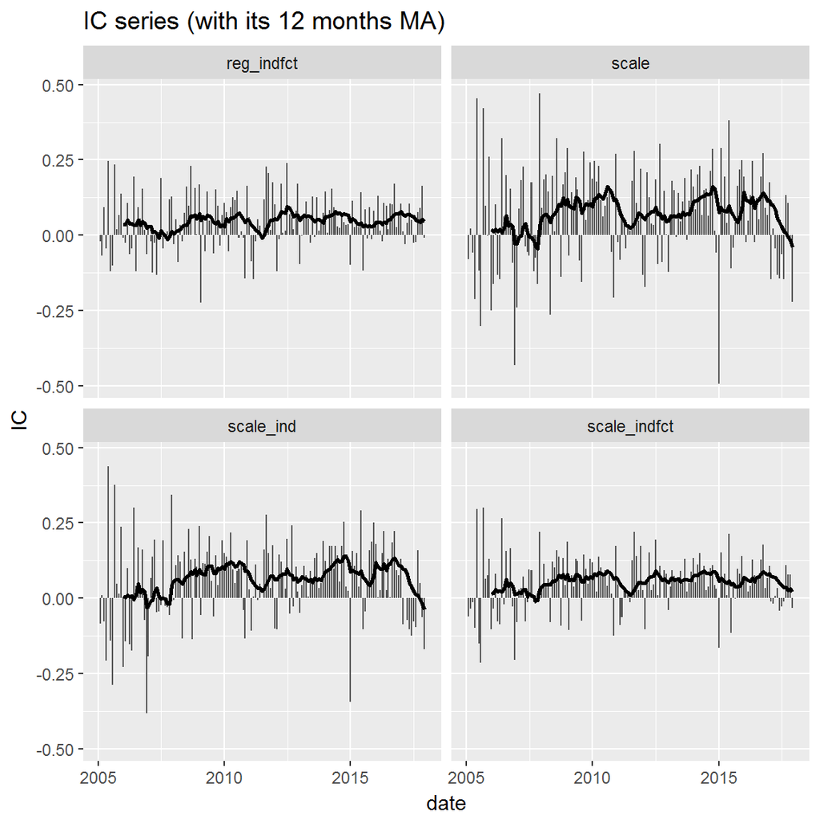

```r
MF.chart.IC(mTSFR = mtsfr,facet_by = 'fname')
```

不同refine方式下因子分组多空收益图

```
## The guessed factorNames are: scale,scale_ind,scale_indfct,reg_indfct.
```

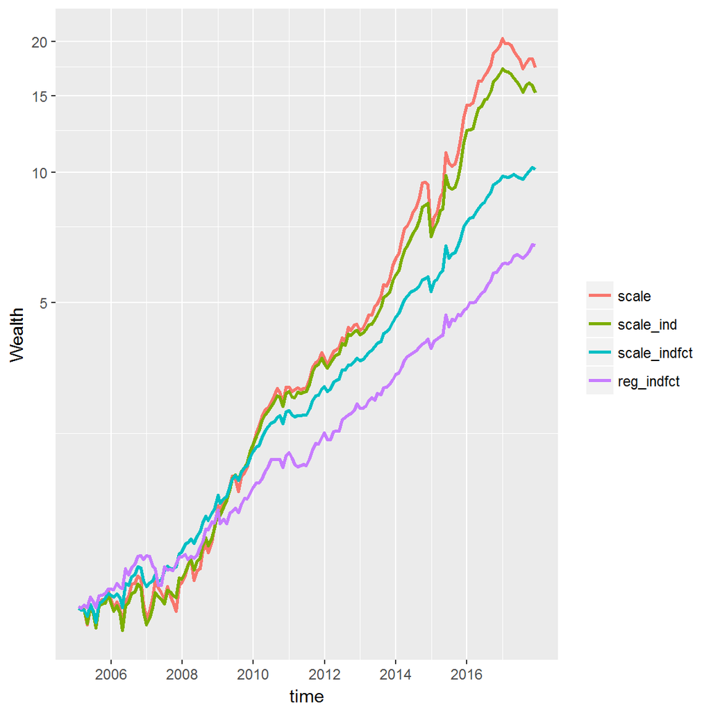

```r
MF.chart.Ngroup.spread(mTSFR = mtsfr, N = 5)
```

不同refine方式下因子分组多空相对收益图

```
## The guessed factorNames are: scale,scale_ind,scale_indfct,reg_indfct.
```

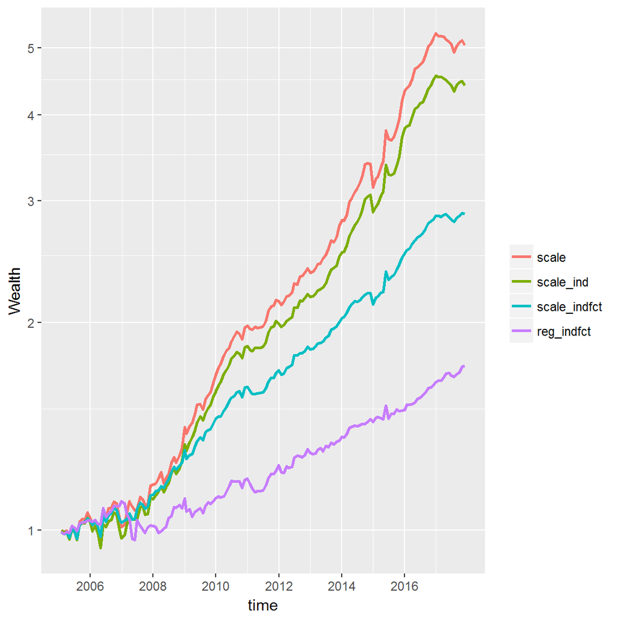

```r
MF.chart.Ngroup.spread(mTSFR = mtsfr, N = 5,rtn_type = "long-univ")
```

不同refine方式下因子IC和分组收益统计表

```r
table_ <- MC.table.ICandNgroup(mTSF2TSFs(mtsfr), N = 5)
```

```
## The guessed factorNames are: scale,scale_ind,scale_indfct,reg_indfct.
```

```r
kable(table_,digits = 2)
```

|  | IC_mean | IC_std | IC_IR | IC_t | IC_p | IC_hitRatio | IC_annu | Annualized Return | Annualized StdDev | Annualized Sharpe(Rf=0%) | HitRatio | Worst Drawdown | Annualized Turnover | Annualized Return (fee cut) | Beta | Size |
| --- | --- | --- | --- | --- | --- | --- | --- | --- | --- | --- | --- | --- | --- | --- | --- | --- |
| scale | 0.07 | 0.16 | 0.41 | 5.05 | 0 | 0.68 | 0.23 | 0.25 | 0.19 | 1.32 | 0.69 | 0.23 | 3.31 | 0.25 | 0.12 | -443.58 |
| scale_ind | 0.06 | 0.13 | 0.45 | 5.62 | 0 | 0.72 | 0.21 | 0.23 | 0.16 | 1.50 | 0.71 | 0.19 | 3.52 | 0.23 | 0.11 | -250.14 |
| scale_indfct | 0.05 | 0.09 | 0.58 | 7.26 | 0 | 0.75 | 0.18 | 0.20 | 0.10 | 1.88 | 0.76 | 0.10 | 4.45 | 0.20 | 0.02 | -189.28 |
| reg_indfct | 0.05 | 0.09 | 0.51 | 6.40 | 0 | 0.70 | 0.16 | 0.16 | 0.10 | 1.58 | 0.68 | 0.15 | 4.36 | 0.16 | -0.08 | 197.72 |

```r
table_ <- data.frame(factorName="ILLIQ",refinePar=rownames(table_),table_,row.names = NULL,stringsAsFactors = FALSE)
tablestats <- rbind(tablestats,table_)
```